# Introduction

I then go through two models offering an “unorthodox” theory of intermediary-based asset pricing, presented in two unpublished papers (Geerolf (2015) and Geerolf (2017)). In Geerolf (2017), I develop a theory of intermediary-based asset pricing, resulting from different skin in the game constraints. Instead of basing intermediary-based asset pricing on intermediaries’ risk aversion, as in He and Krishnamurthy (2013) and Brunnermeier and Sannikov (2014), the theory is based on the scarcity of these different skin in the game constraints. This has some implications which are very similar to intermediary-based asset pricing, such as the increase in risk premia when intermediaries have less wealth (but not because their marginal utility of wealth is then higher!).

# Asset Pricing with Heterogeneous Intermediaries (Geerolf (2017))

## Uniform Distribution

Assuming:
$$\frac{f(\lambda)}{f\left(z(\lambda)\right)}=\frac{\Lambda}{Z}=a$$
The market clearing equation implies:
$$z'(\lambda)=\frac{1-q(\lambda)}{q(\lambda)}a$$

The optimality condition implies:
$$\begin{aligned}
&q'(\lambda)=\dfrac{1-q(\lambda)}{z(\lambda)-\lambda} \quad\Rightarrow\quad z(\lambda)-\lambda=\frac{1-q(\lambda)}{q'(\lambda)}\quad\Rightarrow\quad z'(\lambda)=1+\frac{-q'(\lambda)^{2}-q''(\lambda)(1-q(\lambda))}{q'(\lambda)^{2}}\\
& \Rightarrow\quad\frac{1-q(\lambda)}{q(\lambda)}a=-\frac{q''(\lambda)(1-q(\lambda))}{q'(\lambda)^{2}}\quad\Rightarrow\quad q''(\lambda)q(\lambda)+aq'(\lambda)^{2}=0.
\end{aligned}$$

thus, using $q$ as a shorthand for function $q(\lambda)$:
$$q''q+aq'^{2}=0\quad\Rightarrow\quad\frac{q''}{q}+a\frac{q'^{2}}{q^{2}}=0.$$

Using the change of variable $u\equiv\log(q)$:
$$u'=\frac{q'}{q},\quad u''=\frac{q''q-q'^{2}}{q^{2}}=\frac{q''}{q}-u'^{2}$$

Therefore:
$$\frac{q''}{q}=-au'^{2}\quad\Rightarrow\quad u''=-(a+1)u'^{2}$$

then, the previous differential equation simplifies into:
$$\begin{aligned}
&u''+(a+1)u'^{2}=0\quad\Rightarrow\quad -\frac{u''}{u'^{2}}=a+1\quad\Rightarrow\quad\frac{1}{u'}=(a+1)\lambda-C_{1}\\
&\quad\Rightarrow\quad u'=\frac{1}{(a+1)\lambda-C_{1}} \quad\Rightarrow\quad u(\lambda)=\frac{1}{1+a}\log\left[(a+1)\lambda-C_{1}\right]+\log C_{2}\\
&\quad\Rightarrow\quad q(\lambda)=\exp\left[u(\lambda)\right]=C_{2}\left[(1+a)\lambda-C_{1}\right]^{\frac{1}{1+a}}
\end{aligned}$$

Expected returns are thus given in closed form by:
$$r(\lambda)=\frac{\lambda}{q(\lambda)}=\dfrac{\lambda}{C_{2}\left[(1+a)\lambda-C_{1}\right]^{\frac{1}{1+a}}}.$$

The $q'(\lambda)$ function in the uniform case is:
$$q'(\lambda)=C_{2}\left[(1+a)\lambda-C_{1}\right]^{\frac{1}{1+a}-1}$$

Note that the matching function $z(.)$ can be written only as a function of $q(.)$:
$$\begin{aligned}
z(\lambda) &=\lambda+\frac{1-q(\lambda)}{q'(\lambda)}\\
&=\lambda+\dfrac{1-C_{2}\left[(1+a)\lambda-C_{1}\right]^{\frac{1}{1+a}}}{C_{2}\left[(1+a)\lambda-C_{1}\right]^{\frac{1}{1+a}-1}}\\
z(\lambda) &=\lambda+\frac{1}{C_{2}}\left[(1+a)\lambda-C_{1}\right]^{\frac{a}{1+a}}-\left[(1+a)\lambda-C_{1}\right].
\end{aligned}$$

Finally, $C_{1}$, $C_{2}$ and $\lambda_{m}$ are given by substituting the previous equations:
$$\begin{aligned}
q(\lambda_{m}) &=\lambda_{m}\quad\Rightarrow\quad C_{2}\left[(1+a)\lambda_{m}-C_{1}\right]^{\frac{1}{1+a}}=\lambda_{m}\\
z(\lambda_{m}) &=\underline{z}\quad\Rightarrow\quad\lambda_{m}+\frac{1}{C_{2}}\left[(1+a)\lambda_{m}-C_{1}\right]^{\frac{a}{1+a}}-\left[(1+a)\lambda_{m}-C_{1}\right]=\underline{{z}}\\
z(\bar{\lambda}) &=\bar{{z}}\quad\Rightarrow\quad\bar{\lambda}+\frac{1}{C_{2}}\left[(1+a)\bar{\lambda}-C_{1}\right]^{\frac{a}{1+a}}-\left[(1+a)\bar{\lambda}-C_{1}\right]=\bar{{z}}.
\end{aligned}$$

# Asset Pricing with Disagreement (Geerolf (2015))

In the previous model, I assumed that the lender is involved in monitoring the borrower; or that he has at least is relevant to realized cash flows. Depending on monitoring, borrowers will be able to promise a different return to lender. This model applies well to markets where monitoring is paramount, such as the private equity, the leveraged buy-out, or the subordinated debt market.

In contrast, in my Job Market Paper, I developed a theory of leverage and asset pricing based on belief disagreement between different financial market participants, based on Geanakoplos (1997) and Geanakoplos (2010). This model applies more to financial assets, for which agents may have heterogeneous beliefs. In my job market paper, I showed that with heterogeneous beliefs, lenders get a higher expected return from borrowers’ optimism even if they do not take any risk.

## A Model of Disagreement about Financial Assets

**Environment**:  
- Two periods $0$ and $1$.  
- To simplify notations, I omit the time zero subscript: for example, the price at time $0$ is denoted by $p$ instead of $p_0$.  
- There is a continuum of agents $i \in [0,1]$ of measure one born in period $0$ with initial wealth normalized to $1$.  
- Agents care only about their consumption in period $1$, and therefore need assets to store their wealth.

**Assets** are:
- **Storage Technology** with return normalized to $R=1$. Non-disagreement asset $=$ *Cash*.
- They can also invest in an **Asset** in finite supply normalized to $1$, with exogenous resale value $p_{1}$ in period $1$, and endogenous price $p$ in period $0$, which I will refer to as the *Real Asset* in the following.
- In addition, they can agree to **Collateralized Borrowing Contracts** with each other. Formally, I define a Borrowing Contract in Economy $\mathcal{E_B}$ as follows. A *Borrowing Contract* $(\phi)$ in the Borrowing Economy $\mathcal{E_B}$ is a promise of $\phi \geq 0$ units of Cash in period $1$, the *face value*, collateralized by one unit of Real Asset:
$$\begin{aligned}
\min \lbrace \phi,p_{1}\rbrace
\end{aligned}$$
for a contract with face value $\phi$. In period $0$, this contract is sold by the borrower, who gets $q(\phi)$ units of Cash in exchange for the contract. Interest rate is:
$$\begin{aligned}
r(\phi)=\frac{\phi}{q(\phi)}.
\end{aligned}$$

**Beliefs.** Agents have heterogeneous point expectations about the price of the asset in period 1. Namely, agent $i \in [0,1]$ believes that the asset price will be $p^i_1$ with probability $1$.

More precisely, the cumulative distribution function representing the number of agents with beliefs $p_1^i$ for future prices is denoted by $F(.)$, with corresponding density $f(.)$. The upper bound on agents’ beliefs is assumed to be $1$ without loss of generality. (The model being linear, all quantities in the model are multiplied by $M$ in the case where this maximum belief is $M$.) The most pessimistic agents have beliefs $1-\Delta$, with $\Delta>0$. $f(.)$ has full support on $[1-\Delta,1]$, so $\Delta$ is a natural measure of belief heterogeneity. $\Delta$ will be referred to as the *belief heterogeneity parameter*.

**Equilibrium.** All units of the Real Asset are initially endowed to unmodeled agents who sell their asset holdings in period $0$ and then consume: for example, the model has overlapping generations and the old sell their holdings to the young before they die. Agent $i$ chooses his position in the Real Asset $n_A^i$, a menu of financial Borrowing Contracts $(\phi)$ denoted by $dN_B^i(\phi)$ (where $N_B^i(\phi)$ is the cumulative measure of contracts with face value less then $\phi$), and Cash $n_C^i$, in order to maximize his expected wealth in period $1$ according to his subjective beliefs $p_1^i$ about the Real Asset, subject to his budget constraint, and the collateral constraint (Since agents trade only one contract in equilibrium, the distribution represented by $N_B^i(\phi)$ has a Dirac density.):

$$\begin{aligned}
\max_{(n_A^i, dN_B^i(.),n_C^i)}& n_A^i p_1^i+\int_\phi \min\{\phi,p^i_{1}\}dN_B^i(\phi)+n_C^i\\
&\text{s.t. } \quad n_A^i p+\int_\phi q(\phi)dN_B^i(\phi)+n_C^i \leq 1\\
&\text{s.t. } \quad \int_\phi \max\{0,-dN_B^i(\phi)\} \leq n_A^i\\
&\text{s.t. } \quad n_A^i \geq 0, \quad n_C^i \geq 0
\end{aligned}$$

A for Economy $\mathcal{E_B}$ is a price $p$ for the Real Asset and a distribution of prices $q(.)$ for all traded Borrowing Contracts $(\phi)$, and portfolios $(n_A^i, dN_B^i(.),n_C^i)$ for all agents $i$ in the Real Asset, Borrowing Contracts and Cash, such that all agents $i$ maximize expected wealth in period $1$ according to their subjective beliefs, subject to their budget constraint, their collateral constraint, and markets for the Real Asset and Borrowing Contracts clear:
$$\begin{aligned}
&\int_i n_A^i di=1,\\
\text{and} \quad \forall \phi, \quad & \int_i dN_B^i(\phi)di=0.
\end{aligned}$$

## Making Progress on the Model

A borrower with beliefs $p_1^i$ chooses the face value of the Borrowing Contract $\phi$ to solve:
$$\begin{aligned}
\max _{\phi} \frac{p_1^i-\phi}{p-q(\phi)}.
\end{aligned}$$

$$\begin{aligned}
&\text{Return on Asset}=\frac{p^i_1}{p},\\
&\text{Return on Debt}=\frac{\phi}{q(\phi)}=r(\phi),\\
&\text{Return on Equity}=\frac{p_1^i-\phi}{p-q(\phi)}.
\end{aligned}$$

$$\begin{aligned}
\text{Leverage}&=\frac{p}{p-q(\phi)} \qquad \text{Loan-To-Value}=\frac{q(\phi)}{p}\\ \\
\text{Haircut}&=\frac{p-q(\phi)}{p} \qquad \text{Margin}=\frac{p-q(\phi)}{q(\phi)}.
\end{aligned}$$

$$\begin{aligned}
-\left(p-q(\phi)\right)+q'(\phi)(p_1^i-\phi)=0 \quad \Rightarrow \quad \frac{p_1^i-\phi}{p-q(\phi)}=\frac{1}{q'(\phi)}.
\end{aligned}$$

$$\begin{aligned}
\frac{p_1^i-\phi}{p-q(\phi)}&=\left(1+\frac{q(\phi)}{p-q(\phi)}\right) \frac{p_{1}^i}{p}-\frac{q(\phi)}{p-q(\phi)}r(\phi)\\
\frac{p_1^i-\phi}{p-q(\phi)}&=\frac{p_1^i}{p}+\left(\frac{p_1^i}{p}-r(\phi)\right)\frac{q(\phi)}{p-q(\phi)}.
\end{aligned}$$

**Result 2.** A lender with beliefs $p_1^i$ chooses the face value of the Borrowing Contract equal to $p_1^i$.

If he buys an overcollateralized contract with $\phi<p_1^i$, the lender’s expected payoff is:
$$\begin{aligned}
\frac{\min\{\phi,p_1^i\}}{q(\phi)}=\frac{\phi}{q(\phi)}=r(\phi),
\end{aligned}$$
which is increasing in $\phi$. Hence, the lender will find it optimal to choose $\phi \geq p_1^i$. The lender does not choose an undercollateralized contract either, such that the promise exceeds the expected value of the collateral $\phi>p_1^i$. The expected payoff on an under collateralized contract is:
$$\begin{aligned}
\frac{\min\{\phi,p_1^i\}}{q(\phi)}=\frac{p_1^i}{q(\phi)},
\end{aligned}$$
which is decreasing in $\phi$. Therefore, it has to be that $\phi \leq p_1^i$, so $\phi = p_1^i$.

**Result 3.** More optimistic borrowers borrow with higher leverage ratio loans. They therefore effectively borrow from more optimistic lenders, through their choice of Borrowing Contracts.

There is supermodularity of the expected wealth (and return, both being equivalent) with respect to his beliefs $p_1^i$ and the face value of the Borrowing Contract he uses:
$$\begin{aligned}
\frac{p_1^i-\phi}{p-q(\phi)}&=\frac{p_1^i}{p}+\left(\frac{p_1^i}{p}-r(\phi)\right)\frac{q(\phi)}{p-q(\phi)}.
\end{aligned}$$
Therefore, the cross derivative of wealth with respect to $\phi$ and $p_1^i$ is strictly positive:
$$\begin{aligned}
\frac{\partial^2}{\partial p_1^i \partial \phi}\left(\frac{p_1^i-\phi}{p-q(\phi)}\right)=\frac{q'(\phi)}{\left(1-q(\phi)\right)^2}>0.
\end{aligned}$$
We therefore have that:
$$\begin{aligned}
\frac{\partial}{\partial \phi}\left(\frac{p_1^i-\phi}{p-q(\phi)}\right) = 0 & \quad \Rightarrow \quad \frac{\partial^2}{\partial^2 \phi}\left(\frac{p_1^i-\phi}{p-q(\phi)}\right) d\phi+ \frac{\partial^2 }{\partial p_1^i \partial \phi}\left(\frac{p_1^i-\phi}{p-q(\phi)}\right) dp_1^i=0\\
&\quad \Rightarrow \quad \dfrac{d\phi}{dp_1^i}=-\dfrac{\dfrac{\partial^2}{\partial p_1^i \partial \phi}\left(\frac{p_1^i-\phi}{p-q(\phi)}\right)}{\dfrac{\partial^2}{\partial^2 \phi}\left(\frac{p_1^i-\phi}{p-q(\phi)}\right)} > 0,
\end{aligned}$$
from the fact that $\phi$ maximizes the expected return of the borrower:
$$\begin{aligned}
\dfrac{\partial^2}{\partial^2 \phi}\left(\frac{p_1^i-\phi}{p-q(\phi)}\right)<0 \qquad
\end{aligned}$$
This result has an economic intuition. If a borrower is relatively more optimistic, he likes more buying an extra unit of the asset.

**Result 4.** Market clearing equation.

$$\begin{aligned}
&\underbrace{\frac{f(x)dx}{Q(y)}}_{\begin{subarray}{c}\text{\text{\# of Borrowing Contracts}}\\
\text{bought by lenders in [x,x+dx] }\end{subarray}}=\underbrace{\frac{f(y)dy}{p-Q(y)}}_{\begin{subarray}{c}\text{\text{\# of Borrowing Contracts}}\\
\text{sold by borrowers in [y,y+dy] }\end{subarray}}\\
& \quad \Rightarrow \quad \forall y \in [\tau,1], \quad \left(p-Q(y)\right)f\left(\Gamma(y)\right) \Gamma'(y)= Q(y) f(y).
\end{aligned}$$

Using these notations, we need to replace in the previous optimality condition:
$$\begin{aligned}
\forall y \in [\tau,1], \quad \left(y-\Gamma(y)\right)Q'(y)=\left(p-Q(y)\right)\Gamma'(y).
\end{aligned}$$

**Result 5.** Final and smooth pasting equations. Positive sorting :
$$\begin{aligned}
\Gamma(1)=\tau \qquad \Gamma(\tau)=\xi.
\end{aligned}$$
Indifference of agents with belief $p^i_1=\xi$ :
$$\begin{aligned}
r(\xi)=1 \quad \Rightarrow \quad Q(\tau)=q\left(\Gamma(\tau)\right)=q(\xi)=\xi.
\end{aligned}$$
Indifference of agents with beliefs $p^i_1=\tau$:
$$\begin{aligned}
r(\tau)=\frac{\tau-\xi}{p-\xi} \quad \Rightarrow \quad Q(1)=q\left(\Gamma(1)\right)=q(\tau)=\frac{\tau}{r(\tau)}=\frac{\tau(p-\xi)}{\tau-\xi}.
\end{aligned}$$
Note finally that these equations explain why the marginal buyer of the real asset does not have beliefs equal to the price of the Real Asset, even though the reference asset has an interest rate equal to $R=1$. The marginal buyer has beliefs $p_1^i=\tau>p$, since his outside option is to lend with a return and not to invest in Cash.

Finally, there is market clearing for the Real Asset:
$$\begin{aligned}
p=1-F(\xi).
\end{aligned}$$
The supply of the Real Asset and wealth of each agent are both normalized to one. The left hand side is the total value of the Asset, and the right hand side is the total wealth that purchases these assets.

Subtlety with Walras’ law. Where is it?

**Result 6.** Guessed arrangement is an equilibrium. A sufficient condition for these prices to exist that the following two conditions are satisfied:
$$\begin{aligned}
r'(\xi)>1 \quad \text{and} \quad r'(\tau)<\frac{1}{p-\xi}.
\end{aligned}$$

It is indeed the case in equilibrium. They result from rewriting the assignment equation in terms of the return function using $q(\phi)=\phi/r(\phi)$:
$$\begin{aligned}
\frac{y-\phi}{p-q(\phi)}=\frac{1}{q'(\phi)} \quad \Rightarrow \quad \frac{r'(\phi) \phi}{r(\phi)}=\frac{y-pr(\phi)}{y-\phi}.
\end{aligned}$$

For $\phi=\xi$ we thus we have that:
$$\begin{aligned}
r'(\xi)=\frac{r(\xi)}{\xi}\frac{\tau-pr(\xi)}{\tau-\xi}=\frac{1}{\xi}\frac{\tau-p}{\tau-\xi}>1 \quad \text{since} \quad 1>p>\xi.
\end{aligned}$$
For $\phi=\tau$ this gives:
$$\begin{aligned}
r'(\tau)=\frac{r(\tau)}{\tau}\frac{1-pr(\tau)}{1-\tau}<\frac{r(\tau)}{\tau}=\frac{\tau-\xi}{\tau}\frac{1}{p-\xi}<\frac{1}{p-\xi} \quad \text{since} \quad r(\tau)=\frac{\tau-\xi}{p-\xi}>\frac{\tau}{p}.
\end{aligned}$$

Why are these two inequalities sufficient? One can then construct the prices $q(\phi)$ for non traded Borrowing Contracts $(\phi)$ with $\phi<\xi$ and $\phi>\tau$, such that the return $r(\phi)$ is linear with a slope strictly comprised between $1$ and $r'(\xi)$ for $\phi<\xi$, and linear with a slope strictly comprised between $r'(\tau)$ and $\frac{1}{p-\xi}$ for $\phi>\tau$. Contracts with $\phi<\xi$ are then not demanded by any lender or cash investors because they have negative return, and are not supplied by any borrower because their return does not decrease enough compared to the diminished leverage they offer. Contracts with $\phi>\tau$ are similarly not demanded by any lender because they default for sure for all existing lenders and are more expensive than lower leverage ratio loans. Contracts with $\phi>\tau$ are not supplied by any borrower either as the extra return they would then give is too high.

Moreover, the first inequality guarantees that cash investors with beliefs $p_1^i=\xi^{-}$ (infinitesimally close to the left of $\xi$) do not want to lend rather than invest in cash, and symmetrically that lenders with beliefs $p_1^i=\xi^{+}$ do not want to invest in cash rather than lend. The second inequality guarantees that lenders with beliefs $p_1^i=\tau^{-}$ do not want to be borrowers instead of lenders. Indeed, their return decreases less fast than the levered return $\frac{p_1^i-\xi}{p-\xi}$ they would get from leveraging with contract $(\xi)$: from an envelope condition, one can neglect the corresponding change in the face value of the Borrowing Contract. Symmetrically, it also guarantees that borrowers with beliefs $p_1^i=\tau^{+}$ do not want to lend rather than take a levered bet.

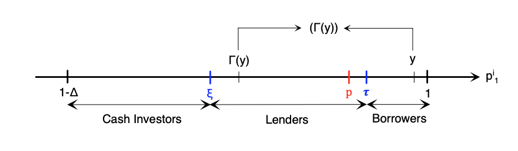

## Uniform Distribution Case

Two non linear first order differential equations. Hard to solve in general.

$$\begin{aligned}
&(p-Q)\Gamma'=Q \quad \Rightarrow \quad \Gamma'=\frac{Q}{p-Q} \quad \Rightarrow \quad y-\Gamma=\frac{Q}{Q'}\\
\quad \Rightarrow \quad 1-\Gamma'=&\frac{Q'^2-Q''Q}{Q'^2} \quad \Rightarrow \quad 1-\frac{Q}{p-Q}=1-\frac{Q''Q}{Q'^2} \quad \Rightarrow_{Q \neq 0} \quad Q''(p-Q)-Q'^2=0.
\end{aligned}$$

This is a non-linear second order differential equation in $Q(.)$, which together with initial conditions $Q(1)$ and $Q'(1)$ forms a well-defined initial value problem. Somewhat unexpectedly, this has a closed form solution as:
$$\begin{aligned}
Q''(p-Q)-Q'^2=0 \quad \Rightarrow \quad \left(Q'(p-Q)\right)'=0 \quad \Rightarrow \quad\left(-\frac{\left(p-Q\right)^2}{2}\right)''=0.
\end{aligned}$$
This together with $Q'(1)=\frac{Q(1)}{1-\Gamma(1)}$ gives $Q(y)$:
$$\begin{aligned}
& -\frac{\left(p-Q(y)\right)^2}{2}=-\frac{\left(p-Q(1)\right)^2}{2}+\frac{Q'(1)\left(p-Q(1)\right)}{1-\Gamma(1)}(y-1)\\
& \quad \Rightarrow \quad Q(\mathbf{y})=p-p\sqrt{\left(1-\frac{Q(1)}{p}\right)^2+2\frac{Q(1)}{p}\left(1-\frac{Q(1)}{p}\right)\frac{1-\mathbf{y}}{1-\Gamma(1)}}
\end{aligned}$$

In particular, the leverage ratio function $\frac{p}{p-Q(\mathbf{y})}$, which is one focus of the paper, can in the same way be expressed explicitly as a function of $\Delta$ only:
$$\begin{aligned}
\frac{p}{p-Q(\mathbf{y})}=\dfrac{1}{\sqrt{\left(1-\dfrac{Q(1)}{p}\right)^2+2\dfrac{Q(1)}{p}\left(1-\dfrac{Q(1)}{p}\right)\dfrac{1-\mathbf{y}}{1-\Gamma(1)}}}.
\end{aligned}$$
One can perhaps already see that it is a truncated Pareto distribution with coefficient $2$, since $\frac{p}{p-Q(\mathbf{y})}$ is of the form $\frac{1}{\sqrt{a+b(1-y)}}$ with $a$ small, and $y$ goes to $1$ uniformly.

A closed form expression for $p$, $\xi$ and $\tau$ in the Borrowing Economy and when the density is uniform with heterogeneity parameter $\Delta$ obtains as follows. If $f$ is uniform, then $F(.)$ is linear with slope $1/\Delta$ so that the market clearing equation writes $\xi=1-p \Delta$. Because $Q'(p-Q)$ is constant, from $\left(\left(p-Q\right)^2\right)''=0$, we have:
$$\begin{aligned}
& Q'(\tau)\left(p-Q(\tau)\right)=Q'(1)\left(p-Q(1)\right) \quad \Rightarrow \quad \frac{Q(\tau)}{1-\Gamma(\tau)}\left(p-Q(\tau)\right)=\frac{Q(1)}{1-\Gamma(1)}\left(p-Q(1)\right)\\
& \quad \Rightarrow \quad \frac{\xi}{\tau-\xi}(p-\xi)=\frac{\tau(p-\xi)}{(\tau-\xi)((1-\tau)}\left(p-\frac{\tau(p-\xi)}{\tau-\xi}\right) \quad \Rightarrow \quad \frac{\tau-\xi}{\tau-p}=\frac{\tau}{1-\tau}.
\end{aligned}$$
Using $\xi=1-p \Delta$, one can express $p$ as a function of $\tau$:
$$\begin{aligned}
(1-\tau)(\tau-1+p\Delta)=\tau(\tau-p) \quad \Rightarrow \quad p=\frac{2\tau^2-2\tau+1}{\Delta+(1-\Delta)\tau}.
\end{aligned}$$
Using the integration of $\left((p-Q)^2\right)''=0$ we also have:
$$\begin{aligned}
\left(p-Q(\tau)\right)^2=\left(p-Q(1)\right)^2+2Q(1)\left(p-Q(1)\right) \quad \Rightarrow \quad (p-Q(\tau))^2=p^2-Q(1)^2.
\end{aligned}$$
Then, we have:
$$\begin{aligned}
p-\xi&=p-(1-\Delta p)=\frac{(1+\Delta) \tau^2+(1+\Delta)(1-\tau)^2-\tau-(1-\tau)\Delta}{\Delta+(1-\Delta)\tau}=\frac{(2\tau-1)\left[(1+\Delta)\tau-1\right]}{\Delta+(1-\Delta)\tau}\\
\tau-\xi&=\tau-1+\Delta p=\frac{(\tau-1)\Delta +(1-\Delta)\tau^2-(1-\Delta)\tau+2\left(2\tau^2-2\tau+1\right)}{\Delta+(1-\Delta)\tau} = \frac{(1+\Delta)\tau-1}{\Delta+(1-\Delta)\tau}\tau.
\end{aligned}$$
Therefore:
$$\begin{aligned}
Q(1)&=\tau\frac{p-\xi}{\tau-\xi}=2\tau-1.
\end{aligned}$$
Equation $(p-\xi)^2=p^2-Q(1)^2$ thus writes:
$$\begin{aligned}
&(2\tau-1)^2\left[(1+\Delta)\tau-1\right]^2=(2\tau^2-2\tau+1)^2-(2\tau-1)^2\left[\Delta+(1-\Delta \tau\right]^2 \\
& \quad \Rightarrow \quad (2\tau-1)^2(1+\Delta^2)(2\tau^2-2\tau+1)=\left(2\tau^2-2\tau+1\right)^2.
\end{aligned}$$
Because $2\tau^2-2\tau+1=\tau^2+(1-\tau)^2 \neq 0$ this implies:
$$\begin{aligned}
(2\tau-1)^2 (1+\Delta^2)=2\tau^2-2\tau+1 \quad \Rightarrow \quad \tau^2-\tau+\frac{2\Delta^2}{4(1+2\Delta^2)}=0 \quad \Rightarrow \quad \tau=\frac{1}{2}\left(1 \pm \sqrt{\frac{1}{1+2\Delta^2}}\right).
\end{aligned}$$
If $\tau$ is the lowest solution then from the implied value of $p$ one can show easily that $\tau-p<0$. This is a contradiction because borrowers would then be expecting negative excess returns on the asset. So the highest solution is the equilibrium one. One then gets a closed form expression for $p$ and $\xi$ as a function of $\Delta$ as well, so that:
$$\begin{aligned}
\tau=\frac{1}{2}+\frac{1}{2\sqrt{1+2\Delta^2}} \qquad \qquad p=\frac{2(1+\Delta^2)}{1+\Delta +2 \Delta^2+2 \Delta^3+(1-\Delta)\sqrt{1+2\Delta^2}} \qquad \xi=1-\Delta p.
\end{aligned}$$

## Results

### Hedonic Interest Rates

In the model, the implicit interest rate on Borrowing Contracts with face value $(\phi)$ is strictly higher than the returns to cash for all $\phi>\xi$:
$$\begin{aligned}
r(\phi)=\frac{\phi}{q(\phi)}=\frac{\Gamma(y)}{Q\left(y\right)}>R=1.
\end{aligned}$$
This occurs while Borrowing Contracts are fully secured according to lenders buying them, as well as borrowers selling them. This result comes from rewriting the borrowers’ problem in terms of the interest rate on the Borrowing Contract $r(\phi)=\phi/q(\phi)$. One then gets:
$$\begin{aligned}
\frac{y-\phi}{p-q(\phi)}=\frac{1}{q'(\phi)} \quad \Rightarrow \quad \frac{r(\phi)^2}{r(\phi)-r'(\phi)\phi}=\frac{y-\phi}{pr(\phi)-\phi}r(\phi) \quad \Rightarrow \quad \frac{r'(\phi) \phi}{r(\phi)}=\frac{y-pr(\phi)}{y-\phi}.
\end{aligned}$$
Borrowers only leverage themselves if the return on the asset is higher than the one they pay on the Borrowing Contract, so that $y/p>r(\phi)$. Moreover $y>\phi$, so that the interest rate function is strictly increasing. With the initial condition $r(\xi)=1$ this proves that the interest rate on Borrowing Contracts is strictly higher than the returns to cash.

### Pareto distribution for Leverage Ratios

Derived on the board during the class.

## Pyramiding

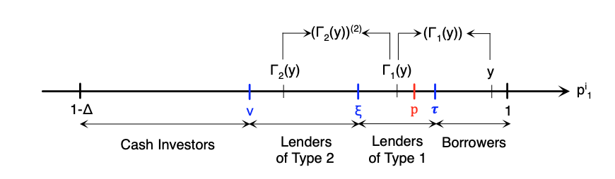

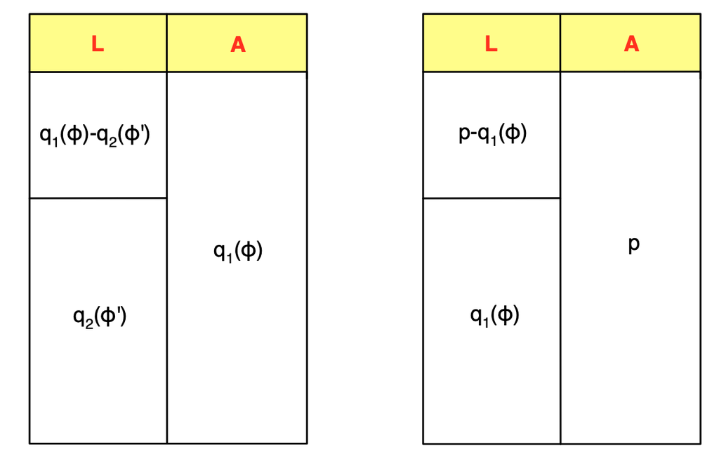

As for the Borrowing Economy, a first equation results from the market clearing for Borrowing Contracts Squared with face value $\Gamma_2(y)=z$. These contracts are bought by lenders of type $2$ in a small interval $[z,z+dz]$, with wealth $f(z)dz$, and sold by lenders of type $1$ in a small interval $[x,x+dx]$. Lenders of type $2$ therefore contribute $Q_2(y)$ to the total loan amount that lenders of type $1$ make to borrowers, and lenders of type $1$ contribute $Q_1(y)-Q_2(y)$ from their own funds. (see the balance sheet below)
$$\begin{aligned}
& \underbrace{\frac{f(z)dz}{Q_2(y)}}_{\begin{subarray}{c}\text{\text{\# of Borrowing Contracts Squared}}\\
\text{bought by lenders of Type 2 in [z,z+dz] }\end{subarray}}=\underbrace{\frac{f(x)dx}{Q_1(y)-Q_2(y)}}_{\begin{subarray}{c}\text{\text{\# of Borrowing Contracts Squared}}\\
\text{sold by lenders of type 1 in [x,x+dx] }\end{subarray}}\\
& \quad \Rightarrow \quad \forall y \in [\tau,1], \quad \left(Q_1(y)-Q_2(y)\right)f\left(\Gamma_2(y)\right) \Gamma_2'(y)= Q_2(y) f\left(\Gamma_1(y)\right) \Gamma_1'(y).
\end{aligned}$$

Moreover, one can write the market clearing for Borrowing Contracts with face value $\Gamma_1(y)=x$. These contracts are bought by lenders of type $1$ (using their own funds and lenders of type $2$’s funds, as seen above) in a small interval $[x,x+dx]$, so that:
$$\begin{aligned}
& \underbrace{\frac{f(x)dx}{Q_1(y)-Q_2(y)}}_{\begin{subarray}{c}\text{\text{\# of Borrowing Contracts}}\\
\text{bought by lenders of Type 1 in [x,x+dx] }\end{subarray}}=\underbrace{\frac{f(y)dy}{p-Q_1(y)}}_{\begin{subarray}{c}\text{\text{\# of Borrowing Contracts}}\\
\text{sold by borrowers in [y,y+dy] }\end{subarray}}\\
& \quad \Rightarrow \quad \forall y \in [\tau,1], \quad \left(p-Q_1(y)\right)f\left(\Gamma_1(y)\right)\Gamma_1'(y)=\left(Q_1(y)-Q_2(y)\right)f(y).
\end{aligned}$$

Multiplying the two sides of the above equations, and keeping the second equation, allows to conclude that the allocation functions are given by the following differential equations:
$$\begin{aligned}
\left(p-Q_1(y)\right)f\left(\Gamma_2(y)\right)\Gamma_2'(y)=Q_2(y)f(y)\\
\left(p-Q_1(y)\right)f\left(\Gamma_1(y)\right)\Gamma_1'(y)=\left(Q_1(y)-Q_2(y)\right)f(y)
\end{aligned}$$

The choice of Borrowers with beliefs $y$ regarding the face value of Borrowing Contracts, gives a first differential equation:
$$\begin{aligned}
\max_{\phi} \frac{y-\phi}{p-q_1(\phi)} &\quad \Rightarrow \quad -\left(p-q_1(\phi)\right)+q'_1(\phi)(y-\phi)=0\\
&\quad \Rightarrow \quad \left(p-Q_1(y)\right)\Gamma_1'(y)=\left(y-\Gamma_1(y)\right)Q'_1(y).
\end{aligned}$$

The choice of Lenders of Type $1$, with beliefs $x_1$, and who choose Borrowing Contracts Squared to lever themselves into the spreads given by traditional Borrowing Contracts, gives a second differential equation:
$$\begin{aligned}
\max_{\phi} \frac{x_1-\phi}{q_1(x_1)-q_2(\phi)} \quad &\Rightarrow \quad -\left(q_1(x_1)-q_2(\phi)\right)+q'_2(\phi)(x_1-\phi)=0\\
\quad & \Rightarrow \quad \left(Q_1(y)-Q_2(y)\right)\Gamma'_2(y)=\left(\Gamma_1(y)-\Gamma_2(y)\right)Q'_2(y).
\end{aligned}$$

Just as previously, the market clearing equation for the real asset writes:
$$\begin{aligned}
1-F(\nu)=p.
\end{aligned}$$
This is because now the funds of Lenders of type $2$ are also invested in the asset. Positive sorting at the boundaries brings:
$$\begin{aligned}
\Gamma_1(\tau)=\xi, \quad \Gamma_1(1)=\tau, \quad \Gamma_2(\tau)=\nu, \quad \Gamma_2(1)=\xi.
\end{aligned}$$

Finally, indifference for agents with beliefs $\nu$, $\xi$, and $\tau$ respectively imply:
$$\begin{aligned}
1=\frac{\nu}{q_2(\nu)} \quad & \Rightarrow \quad Q_2(\tau)=\nu\\
\frac{\xi}{q_2(\xi)}=\frac{\xi-\nu}{q_1(\xi)-q_2(\nu)} \quad & \Rightarrow \quad \frac{\xi}{Q_2(1)}=\frac{\xi-\nu}{Q_1(\tau)-Q_2(\tau)} \quad \Rightarrow \quad \frac{\xi}{Q_2(1)}=\frac{\xi-\nu}{Q_1(\tau)-\nu}\\
\frac{\tau-\xi}{q_1(\tau)-q_2(\xi)}=\frac{\tau-\xi}{p-q_1(\xi)} \quad & \Rightarrow \quad \frac{\tau-\xi}{Q_1(1)-Q_2(1)}=\frac{\tau-\xi}{p-Q_1(\tau)}.
\end{aligned}$$

Note that this arrangement is actually equivalent to tranching: out of the $p_1$ expected in period $1$, $\phi-\phi'$ is promised to lender of type $1$, and $\phi'$ is promised to lender of type $2$.

Brunnermeier, Markus K., and Yuliy Sannikov. 2014. “A Macroeconomic Model with a Financial Sector.” *American Economic Review* 104 (2): 379–421. doi:10.1257/aer.104.2.379.

Campbell, John Y. 2017. *Financial Decisions and Markets: A Course in Asset Pricing*. Princeton University Press.

Geanakoplos, John. 1997. “Promises Promises.” In *The Economy as an Evolving Complex System II*, edited by D Lane B Arthur S Durlauf, Addison-We, 285–320. Reading, MA: SFI Studies in the Sciences of Complexity.

———. 2010. “The Leverage Cycle.” *NBER Macroeconomics Annual 2009* Volume 24 (April): 1–65. http://www.nber.org/chapters/c11786.

Geerolf, François. 2015. “Leverage and Disagreement.” *Working Paper*, 1–61.

———. 2017. “Asset Pricing with Heterogeneous Intermediaries.” *Working Paper*, 1–52.

He, Zhiguo, and Arvind Krishnamurthy. 2013. “Intermediary Asset Pricing.” *American Economic Review* 103 (2): 732–70. doi:10.1257/aer.103.2.732.